# Predicting Daily High Temperature Using XGBoost

Los Angeles International Airport (KLAX)

Alex Lewis

David Moe

Advisor: Dr. Cohen

2026-07-19

## Introduction

- Daily high temperature forecasting is useful for energy-demand planning, aviation, transportation, and public safety (Wang et al. 2023).
- Operational decisions are usually made from site-specific weather conditions rather than broad regional observations.
- Most forecasting studies emphasize broader regional prediction problems, leaving room for local daily temperature prediction to be explored (Khan and Al-Hajj 2025; Dias et al. 2018).

## Introduction Continued

- Ensemble models have improved weather forecasting by capturing nonlinear relationships in meteorological data (Airlangga 2025).
- XGBoost has shown strong performance in weather-related applications such as precipitation forecasting (Dong et al. 2023).
- This study asks: **Can XGBoost accurately predict daily high temperatures at KLAX using 5-minute NOAA ASOS observations?**

## Introduction Continued

- **Dataset:** National Oceanic and Atmospheric Administration (NOAA) Automated Surface Observing System (ASOS) (Environmental Information (NCEI) 2026)
  - Location: Los Angeles International Airport (KLAX) station
  - 5-minute interval weather measurements
- **Method:** An XGBoost regression model is developed to predict daily high temperature (Chen and Guestrin 2016).
- **Metrics:** Performance is evaluated using MAE, MSE, RMSE, $R^2$, MAPE, and explained variance, and feature importance is analyzed to interpret the model (Zhou 2023; Singh and Rawat 2023; Wiens et al. 2025).

## Methods

- **Target:** Daily maximum air temperature, $T_{max}$, at KLAX
- **Model:** XGBoost regression trees
- XGBoost is well suited for tabular meteorological data:
  - Models nonlinear effects and interactions among predictors.
  - Handles missing values from sensor malfunctions without imputation.

## Methods Continued

- Prediction is the sum of many boosted regression trees (Chen and Guestrin 2016).

$$\hat{y}_i = \sum_{k=1}^{K} f_k(\mathbf{x}_i), \qquad f_k \in \mathcal{F} \tag{1}$$

- The model is trained to balance fit and complexity through regularization.

$$\mathcal{L} = \sum_{i} l(\hat{y}_i, y_i) + \sum_{k=1}^{K} \left[ \gamma T_k + \tfrac{1}{2}\lambda \lVert w_k \rVert^2 \right] \tag{2}$$

- The loss term measures prediction error, while the penalty term discourages overly complex trees.

## Data Exploration and Visualization

### Data Source

- Obtained from National Oceanic and Atmospheric Administration (NOAA) National Centers for Environmental Information (NCEI) Automated Surface Observing System (ASOS) network (Environmental Information (NCEI) 2026)
- ASOS is the primary U.S. airport-based surface weather observing network and provides continuous meteorological observations
- This study uses the Los Angeles International Airport (KLAX) station
- Observations were recorded at 5-minute intervals
- **Study period:** January 1, 2000 to June 7, 2026, covering more than 26 years of records

## Data Exploration and Visualization

### Dataset Structure

- Dataset contains 2,523,612 total 5-minute observations from KLAX
- Variables include Wind direction, wind speed, wind gust, visibility, temperature, dew point, relative humidity, and altimeter pressure
- The modeling target is daily high temperature
- Final target series contains 9,336 daily high-temperature values

## Visualizations and Insights

- Daily High Time Series
- Monthly Boxplot
- Daily High Ranges

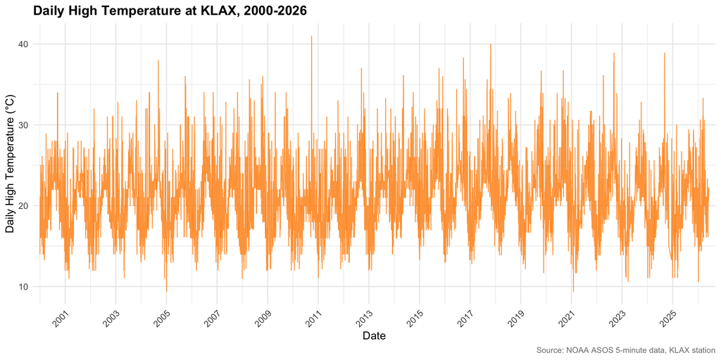

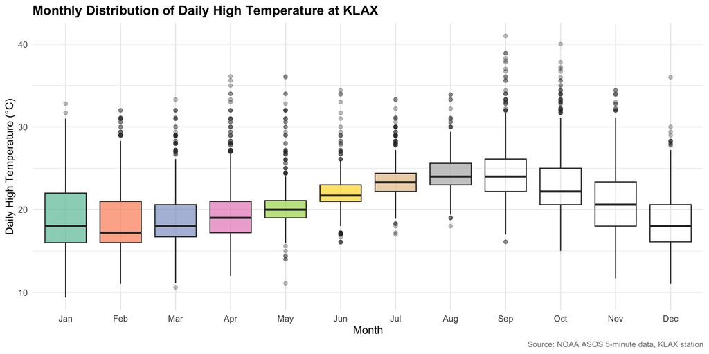

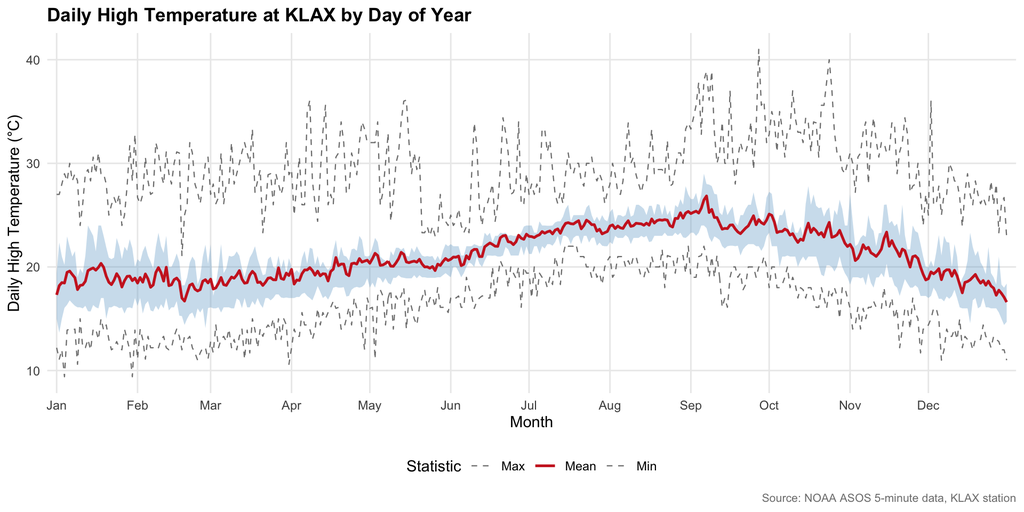

## Visualizations and Insights Continued

- Daily High Histogram
- 3-Hour Temp Change by Wind Group
- Diurnal Cycle

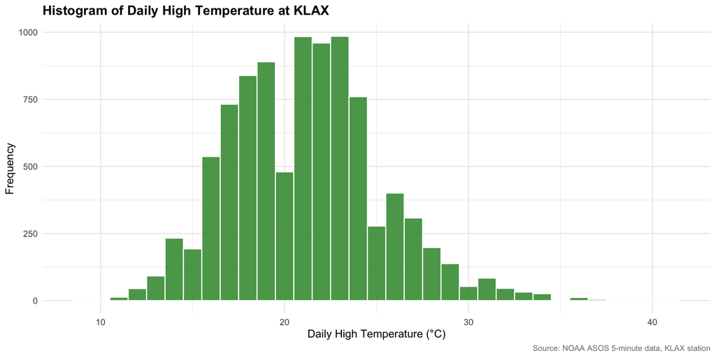

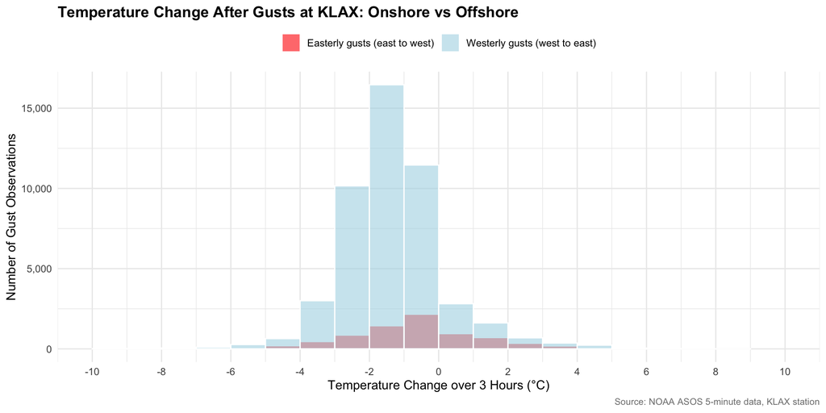

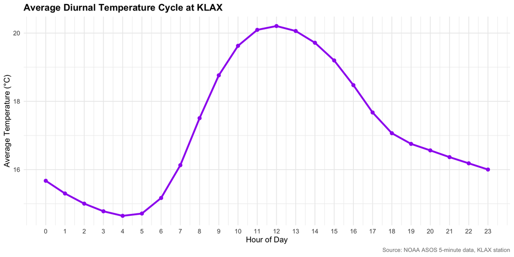

## Modeling and Results

### Preprocessing

- **Raw input:** KLAX 5-minute ASOS observations from 2000–2026, including temperature, dewpoint, humidity, wind, visibility, and altimeter pressure.
- **Sorting:** Sorted chronologically to preserve temporal order for training and evaluation.
- **Sensor errors:** Checking for sensor errors or anomalies.
  - Visibility values above 10 statute miles were capped because ASOS visibility is reported as 10SM when visibility is 10 miles or greater.
  - Wind gusts above 100 kt were removed as implausible extremes relative to the study objective.
- **Missing-values:** Infinite values were relabeled as missing rather than imputed, given XGBoost’s native handling of missing values in tree models.

## Modeling and Results

### Feature Engineering

- **Target:** Daily high temperature defined as the maximum 5-minute temperature within each calendar day.
- **Lagged features:** Previous-day high temperature, along side daily summary statistics such as mean, minimum, and standard deviation were created to capture persistence.
- **Same-day forecasting window:** Only observations prior to 11:00 A.M. were used so the model relies on information available before the typical high time window.
- **Night vs. morning windows:** Separate 0–6 A.M. and 6–11 A.M. feature windows captured overnight conditions and morning atmospheric change.
- **Seasonality features:** Year, month, day-of-year terms, sinusoidal seasonality, and seasonal indicators helped the model represent annual structure.

## Modeling and Results

### XGBoost

- Model Choice
- Model Parameters
- **Model:** XGBoost regression - captures nonlinear relationships and interactions common in meteorological data, while also handling missing values natively.
- **Dataset Split:** The dataset was split by year. There are a total of 9,336 daily high target observations.
  - **Train Split:** 2000–2018, consists of 6,800 (72.84%) observations
  - **Evaluation Split:** 2019–2026, consists of 2,536 (27.16%) observations
- **Model Parameters:** Small learning rate and 800 boosting rounds allowed gradual learning.

| Hyperparameter | Value |
| --- | --- |
| Objective Function | `Squared Error` |
| Learning Rate | `0.03` |
| Subsample of Rows | `0.8` |
| Subsample of Columns | `0.8` |
| Minimum Child Weight | `5` |
| Number of Rounds | `800` |
| Early Stopping | `50` |

## Modeling and Results

### Metrics

Metric Results from XGBoost Model

| Metric | Value |
| --- | --- |
| MAE | 0.873 |
| MSE | 1.609 |
| RMSE | 1.268 |
| R Squared | 0.904 |
| MAPE % | 4.367 |
| Explained Variance | 0.904 |

## Modeling and Results

### Featrue Importance

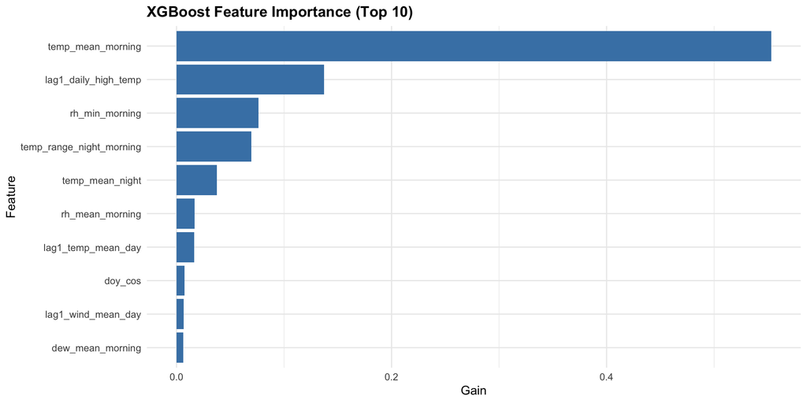

## Modeling and Results

### Diagnostics

- Predicted vs. Actual Daily Highs
- Residuals vs. Actual Daily Highs

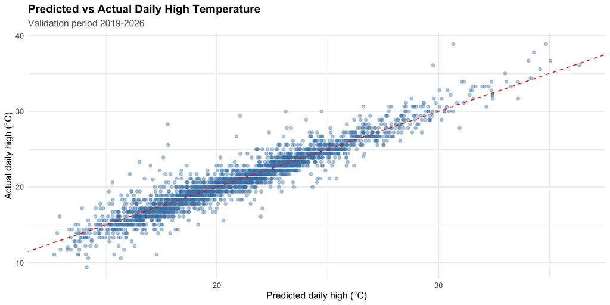

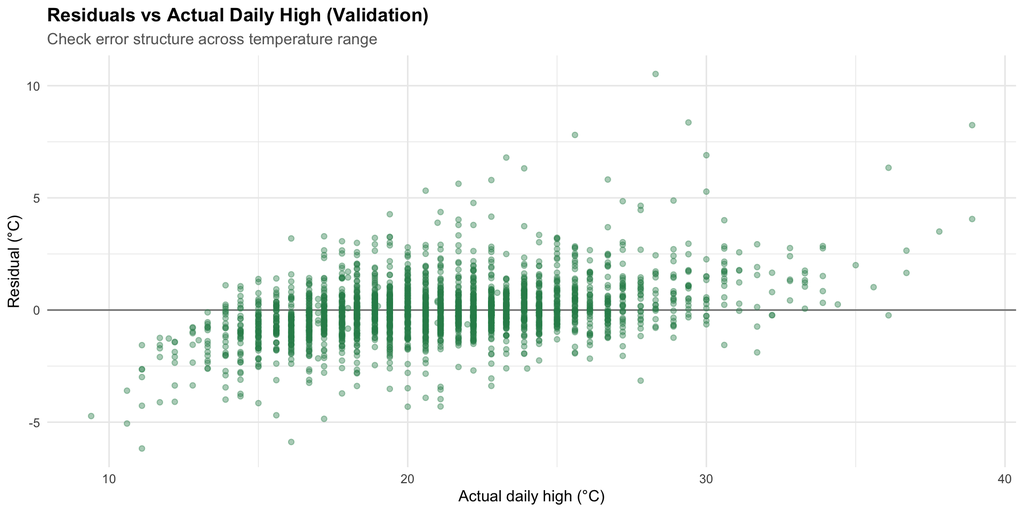

## References

Airlangga, Gregorius. 2025. “Comparative Study of Machine Learning Models for Temperature Prediction: Analyzing Accuracy, Stability, and Generalization.” *Building of Informatics, Technology and Science (BITS)* 6 (4): 2672–80. https://doi.org/10.47065/bits.v6i4.7114.

Chen, Tianqi, and Carlos Guestrin. 2016. “XGBoost: A Scalable Tree Boosting System.” *Proceedings of the 22nd ACM SIGKDD International Conference on Knowledge Discovery and Data Mining*, KDD ’16, August, 785–94. https://doi.org/10.1145/2939672.2939785.

Dias, Daniela F., Daniel R. Cayan, and Alexander Gershunov. 2018. *Statistical Prediction of Minimum and Maximum Air Temperature in California and Western North America*. CCCA4-CEC-2018-011. California Energy Commission. https://www.energy.ca.gov/sites/default/files/2019-11/Projections_CCCA4-CEC-2018-011_ADA.pdf.

Dong, Jianhua, Wenzhi Zeng, Lifeng Wu, Jiesheng Huang, Thomas Gaiser, and Amit Kumar Srivastava. 2023. “Enhancing Short-Term Forecasting of Daily Precipitation Using Numerical Weather Prediction Bias Correcting with XGBoost in Different Regions of China.” *Engineering Applications of Artificial Intelligence* 117: 105579. https://doi.org/https://doi.org/10.1016/j.engappai.2022.105579.

Environmental Information (NCEI), NOAA National Center for. 2026. *Automated Surface Observing System (ASOS) Five-Minute Data*. https://www.ncei.noaa.gov/data/automated-surface-observing-system-five-minute/access/.

Khan, S. S., and R. Al-Hajj. 2025. “Multi-Output Deep Learning for High-Frequency Prediction of Air and Surface Temperature in Kuwait.” *Scientific Reports* 15 (39027): 39027. https://doi.org/10.1038/s41598-025-23455-4.

Singh, Deepnita, and Nisha Rawat. 2023. “Machine Learning for Weather Forecasting: XGBoost Vs SVM Vs Random Forest in Predicting Temperature for Visakhapatnam.” *International Journal of Intelligent Systems and Applications*. https://api.semanticscholar.org/CorpusID:262993809.

Wang, Han, Jiachuan Yang, Guangzhao Chen, Chao Ren, and Jize Zhang. 2023. “Machine Learning Applications on Air Temperature Prediction in the Urban Canopy Layer: A Critical Review of 2011–2022.” *Urban Climate* 49: 101499. https://doi.org/https://doi.org/10.1016/j.uclim.2023.101499.

Wiens, Matthew, Alissa Verone-Boyle, Nick Henscheid, Jagdeep T. Podichetty, and Jackson Burton. 2025. “A Tutorial and Use Case Example of the eXtreme Gradient Boosting (XGBoost) Artificial Intelligence Algorithm for Drug Development Applications.” *Clinical and Translational Science* 18 (3): e70172. https://doi.org/https://doi.org/10.1111/cts.70172.

Zhou, Xiang. 2023. “Comparison of Average Temperature Prediction Based on XGBoost and Prophet Models.” *Highlights in Science, Engineering and Technology* 76: 572–78. https://doi.org/10.54097/x2s0s641.